# Context and Defining Problem Statement

Objective

To predict the concrete strength using the data available in file "concrete.csv". Apply feature engineering and model tuning to obtain 85% to 95% accuracy.

Steps and Tasks:

### Exploratory Data Quality Report Reflecting the Following:

Univariate analysis –data types and description of the independent attributes which should include (name, range of values observed, central values (mean and median), standard deviation and quartiles, analysis of the body of distributions/tails, missing values, outliers, duplicates(10 Marks)

Bi-variate analysis between the predictor variables and between the predictor variables and target column. Comment on your findings in terms of their relationship and degree of relation if any. Visualize the analysis using boxplots and pair plots, histograms, or density curves. (10 marks)

### Feature Engineering techniques(10 marks)

Identify opportunities (if any) to extract new features from existing features, drop a feature(if required) Hint: Feature Extraction, for example, consider a dataset with two features length and breadth. From this, we can extract a new feature Area which would be length * breadth.

Get the data model ready and do a train test split.

Decide on the complexity of the model, should it be a simple linear model in terms of parameters or would a quadratic or higher degree.

### Creating the Model and Tuning It:

Algorithms that you think will be suitable for this project. Use Kfold Cross-Validation to evaluate model performance. Use appropriate metrics and make a DataFrame to compare models w.r.t their metrics. (at least 3 algorithms, one bagging and one boosting based algorithms have to be there). (15 marks)

Techniques employed to squeeze that extra performance out of the model without making it overfit. Use Grid Search or Random Search on any of the two models used above. Make a DataFrame to compare models after hyperparameter tuning and their metrics as above. (15 marks)

### Steps:

```
 1. Data loading and preprocessing

 2.Exploratory Data Analysis (20 marks)
   2A. Univariate Analysis
   2B. Bi-Varioate Analysis

 3.Feature Engineering Techniques (10 marks)

 4.Model building and evaluation (15 marks)

 5.Model Tuning (15 marks)
```

### 1. Data loading and preprocessing

```python
#Import necessary libraries
%matplotlib inline
import numpy as np
import pandas as pd
import matplotlib.pyplot as plt
import seaborn as sns
import warnings
warnings.filterwarnings("ignore")  # Not always recommended, but jsut so our notebook looks clean for this activity
```

```python
df = pd.read_csv("concrete.csv")  # Read the input data
```

### 2.Exploratory Data Analysis (20 marks)

#### Basic Check

```python
print ("Shape of Data")
print (df.shape)
print ("")
print ("Columns")
print (df.columns)
print ("")
```

```
Shape of Data
(1030, 9)

Columns
Index(['cement', 'slag', 'ash', 'water', 'superplastic', 'coarseagg',
       'fineagg', 'age', 'strength'],
      dtype='object')
```

```python
df.info()
```

```
<class 'pandas.core.frame.DataFrame'>
RangeIndex: 1030 entries, 0 to 1029
Data columns (total 9 columns):
 #   Column        Non-Null Count  Dtype
---  ------        --------------  -----
 0   cement        1030 non-null   float64
 1   slag          1030 non-null   float64
 2   ash           1030 non-null   float64
 3   water         1030 non-null   float64
 4   superplastic  1030 non-null   float64
 5   coarseagg     1030 non-null   float64
 6   fineagg       1030 non-null   float64
 7   age           1030 non-null   int64
 8   strength      1030 non-null   float64
dtypes: float64(8), int64(1)
memory usage: 72.5 KB
```

```python
df.isnull().sum()
```

```
cement          0
slag            0
ash             0
water           0
superplastic    0
coarseagg       0
fineagg         0
age             0
strength        0
dtype: int64
```

### 2A. Univariate Analysis

##### To see the distribution of all continous variables:

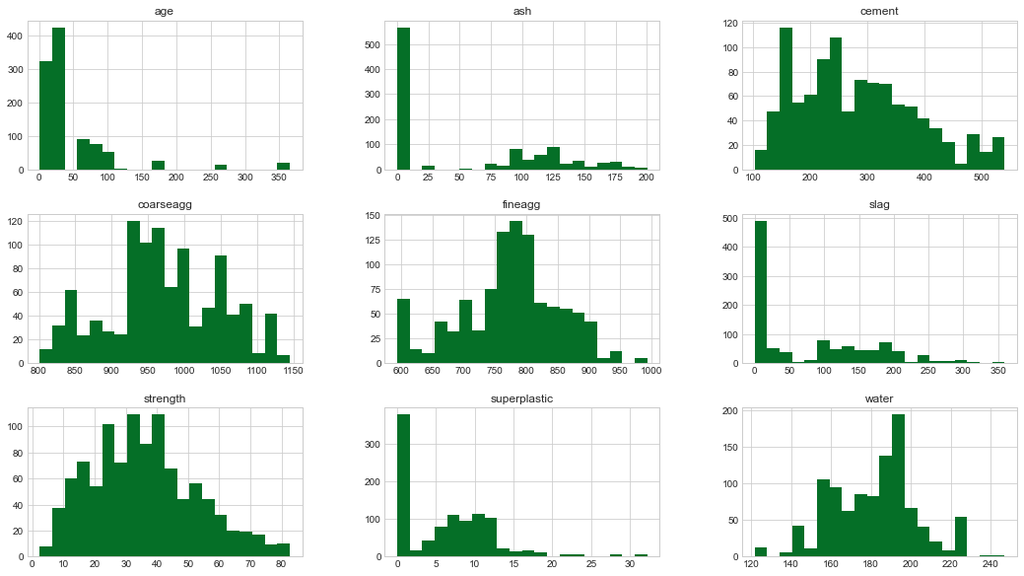

```python
import matplotlib.pyplot as plt
plt.style.use('seaborn-whitegrid')
df[df.columns].hist(bins=20, figsize=(18,10), color='#056F27')
plt.show()
```

```python
print ( str( round((df[df['ash'] <= 0]['ash'].count() / df['ash'].count())*100,2) ) + '% of ash field values are <= 0'   )
print ( str( round((df[df['slag'] <= 0]['slag'].count() / df['slag'].count())*100,2) ) + '% of slag field values are <= 0')
print ( str( round((df[df['superplastic'] <= 0]['superplastic'].count() / df['superplastic'].count())*100,2) ) + '% of superplastic field values are <= 0')
```

```
54.95% of ash field values are <= 0
45.73% of slag field values are <= 0
36.8% of superplastic field values are <= 0
```

#### Insights:

[output not shown]

###### To see the distribution of Target variable "strength" for the zero field values

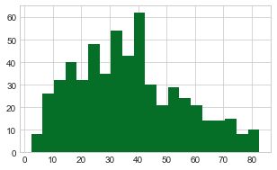

```python
df[df['ash']<=0]['strength'].hist(bins=20, figsize=(5,3), color='#056F27')
```

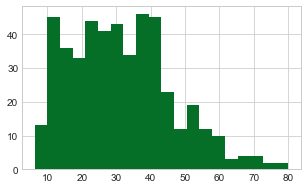

```python
df[df['slag']<=0]['strength'].hist(bins=20, figsize=(5,3), color='#056F27')
```

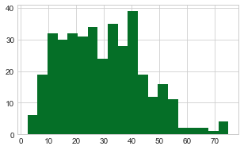

```python
df[df['superplastic']<=0]['strength'].hist(bins=20, figsize=(5,3), color='#056F27')
```

### 2B. Bi-Variate Analysis

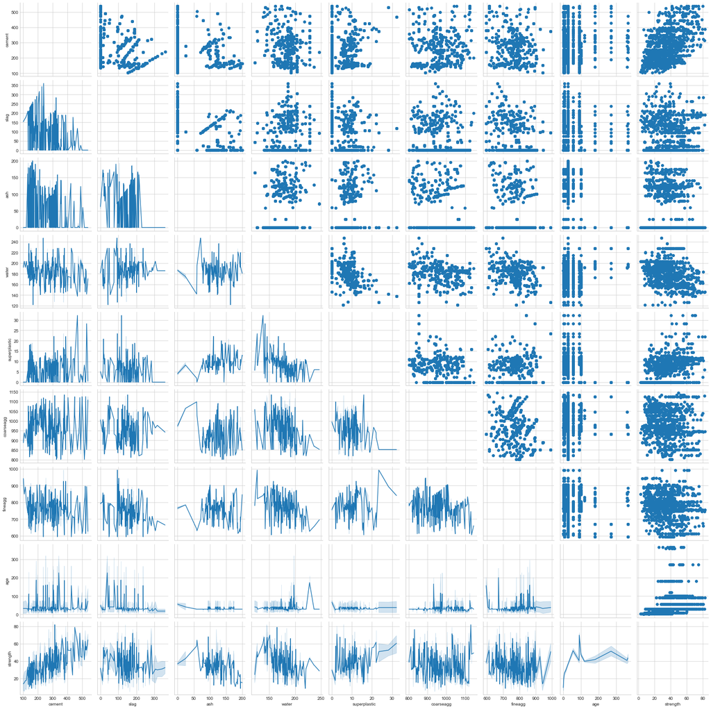

```python
# pair plot

concrete_pp = sns.PairGrid(df)
concrete_pp.map_upper(plt.scatter)
concrete_pp.map_lower(sns.lineplot)
```

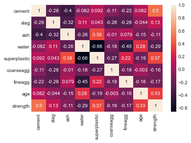

```python
# To see correlation between different variables
cor = df.corr()
sns.heatmap(cor,annot=True)
```

##### Correlation with strength:

strength has positive relationship with the below fields in the same order

```
- cement
- superplastic
- age
```

strength has negative relationship with

```
- water
- coarseagg
- fineagg
```

##### Correlation between variables:

[output not shown]

##### Looking at the scatter plot, strength looks to be scattered all over for below fields

```
    Slag, ash, fineagg and courseagg
    And so these fields may be weak predictors
```

### 3.Feature Engineering Techniques (10 marks)

```
-train_test_split is used to prepare input data to build model for the different possible iterations:

    iteration_1 - All data
    iteration_2 - outlier treated data
    iteration_3 - All data with removing weak predictors
    iteration_4 - outlier treated data with removing weak predictors
```

Model scores and Cross validation score can be compared for different models and iterations to choose the best model & data input

#### Outlier Analysis / Treatmenet

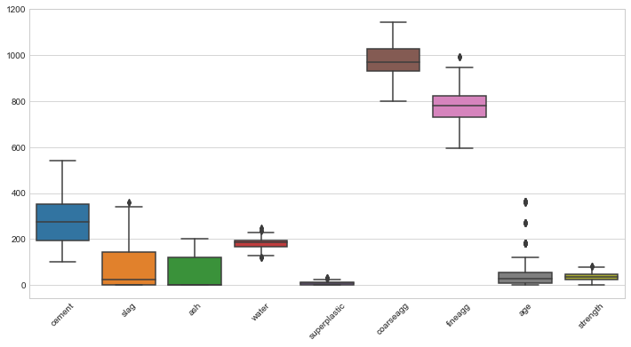

```python
# Plot beofore outlier treatment
plt.subplots(figsize=(12, 6))
ax = sns.boxplot(data=df)
ax.set_xticklabels(ax.get_xticklabels(), rotation=45);
```

```python
# Below code can be used to remove all outlier rows
from scipy import stats
import numpy as np
z = np.abs(stats.zscore(df))

df_out_treated = df[(z < 3).all(axis=1)]
```

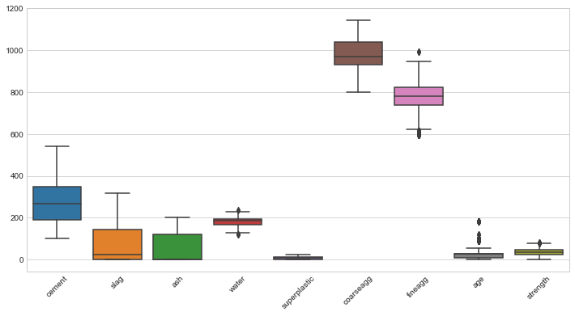

```python
# Plot after outlier treatment
plt.subplots(figsize=(12, 6))
ax = sns.boxplot(data=df_out_treated)
ax.set_xticklabels(ax.get_xticklabels(), rotation=45);
```

```python
print (df.shape)
print (df_out_treated.shape)
```

```
(1030, 9)
(981, 9)
```

#### Create train and test datasets for iterations of data input

- Use train_test_split

```python
# Iteration 1
X = df [['cement', 'slag', 'ash', 'water', 'superplastic', 'coarseagg',
       'fineagg', 'age']]

y = df [['strength']]

from sklearn.model_selection import train_test_split # Splitting the data for training and testing out model

X_train, X_test, y_train, y_test = train_test_split(X,y, random_state = 1)


print (X_train.shape)
print (X_test.shape)
print (y_train.shape)
print (y_test.shape)
```

```
(772, 8)
(258, 8)
(772, 1)
(258, 1)
```

```python
# Iteration 2
X_out = df_out_treated [['cement', 'slag', 'ash', 'water', 'superplastic', 'coarseagg',
       'fineagg', 'age']]

y_out = df_out_treated [['strength']]

from sklearn.model_selection import train_test_split # Splitting the data for training and testing out model

X_train_out, X_test_out, y_train_out, y_test_out = train_test_split(X_out,y_out, random_state = 1)


print (X_train_out.shape)
print (X_test_out.shape)
print (y_train_out.shape)
print (y_test_out.shape)
```

```
(735, 8)
(246, 8)
(735, 1)
(246, 1)
```

```python
# Iteration 3 (removing weak predictors Slag, ash, fineagg and courseagg)
X_no_wk = df [['cement', 'water', 'superplastic',
        'age']]

y_no_wk = df [['strength']]

from sklearn.model_selection import train_test_split # Splitting the data for training and testing out model

X_train_no_wk, X_test_no_wk, y_train_no_wk, y_test_no_wk = train_test_split(X_no_wk,y_no_wk, random_state = 1)


print (X_train_no_wk.shape)
print (X_test_no_wk.shape)
print (y_train_no_wk.shape)
print (y_test_no_wk.shape)
```

```
(772, 4)
(258, 4)
(772, 1)
(258, 1)
```

```python
# Iteration 4
X_out_no_wk = df_out_treated [['cement', 'water', 'superplastic',
        'age']]

y_out_no_wk = df_out_treated [['strength']]

from sklearn.model_selection import train_test_split # Splitting the data for training and testing out model

X_train_out_no_wk, X_test_out_no_wk, y_train_out_no_wk, y_test_out_no_wk = train_test_split(X_out_no_wk,y_out_no_wk, random_state = 1)


print (X_train_out_no_wk.shape)
print (X_test_out_no_wk.shape)
print (y_train_out_no_wk.shape)
print (y_test_out_no_wk.shape)
```

```
(735, 4)
(246, 4)
(735, 1)
(246, 1)
```

### 4.Model building and evaluation (15 marks)

```python
from sklearn.linear_model import LinearRegression, Ridge, Lasso
from sklearn.tree import DecisionTreeRegressor
from sklearn.ensemble import RandomForestRegressor, AdaBoostRegressor, GradientBoostingRegressor
from sklearn.model_selection import KFold, cross_val_score
from sklearn.preprocessing import PolynomialFeatures
from sklearn.ensemble import BaggingRegressor
```

```python
# Function to append scores to series
def append_scores(m,r,a,b,c,d):
    X_train=a
    y_train=b
    X_test=c
    y_test=d
    reg=r
    model_name=m

    training_score = reg.score(X_train, y_train)
    testing_score=reg.score(X_test, y_test)

    cross_vals = cross_val_score(reg, X, y, cv=3)
    mean=cross_vals.mean()
    std=cross_vals.std()
    start_interval = round((mean-(1.96*std)),2)
    end_interval = round((mean+(1.96*std)),2)
    confidence_interval=    str(start_interval) + ' to ' + str(end_interval)

    Model.append(model_name)
    Training_Score.append(training_score)
    Testing_Score.append(testing_score)
    K_Fold_Mean.append(mean)
    K_Fold_Std.append(std)
    Conidence_Interval_95.append(confidence_interval)
```

```python
# Function to build different models for the different input data (iterations)
def model_building_and_append_scores (i,a,b,c,d):

    iteration=i
    X_train=a
    y_train=b
    X_test=c
    y_test=d


    model = LinearRegression()
    reg = model.fit(X_train, y_train)
    Iteration.append(iteration)
    append_scores("Linear Regression",reg,X_train,y_train,X_test,y_test)


    poly = PolynomialFeatures(degree=2, interaction_only=True)
    X_train2 = poly.fit_transform(X_train)
    X_test2 = poly.fit_transform(X_test)
    reg = LinearRegression().fit(X_train2, y_train)
    Iteration.append(iteration)
    append_scores("Linear Regression with poly 2 degree",reg,X_train2,y_train,X_test2,y_test)


    poly = PolynomialFeatures(degree=3, interaction_only=True)
    X_train2 = poly.fit_transform(X_train)
    X_test2 = poly.fit_transform(X_test)
    reg = LinearRegression().fit(X_train2, y_train)
    Iteration.append(iteration)
    append_scores("Linear Regression with poly 3 degree",reg,X_train2,y_train,X_test2,y_test)


    model = Ridge()
    reg = model.fit(X_train, y_train)
    Iteration.append(iteration)
    append_scores("Ridge Regression",reg,X_train,y_train,X_test,y_test)


    poly = PolynomialFeatures(degree=2, interaction_only=True)
    X_train2 = poly.fit_transform(X_train)
    X_test2 = poly.fit_transform(X_test)
    reg = Ridge().fit(X_train2, y_train)
    Iteration.append(iteration)
    append_scores("Ridge Regression with poly 2 degree",reg,X_train2,y_train,X_test2,y_test)


    poly = PolynomialFeatures(degree=3, interaction_only=True)
    X_train2 = poly.fit_transform(X_train)
    X_test2 = poly.fit_transform(X_test)
    reg = Ridge().fit(X_train2, y_train)
    Iteration.append(iteration)
    append_scores("Ridge Regression with poly 3 degree",reg,X_train2,y_train,X_test2,y_test)


    model = Lasso()
    reg = model.fit(X_train, y_train)
    Iteration.append(iteration)
    append_scores("Lasso Regression",reg,X_train,y_train,X_test,y_test)


    poly = PolynomialFeatures(degree=2, interaction_only=True)
    X_train2 = poly.fit_transform(X_train)
    X_test2 = poly.fit_transform(X_test)
    reg = Lasso(alpha=1.0).fit(X_train2, y_train)
    Iteration.append(iteration)
    append_scores("Lasso Regression with poly 2 degree",reg,X_train2,y_train,X_test2,y_test)


    poly = PolynomialFeatures(degree=3, interaction_only=True)
    X_train2 = poly.fit_transform(X_train)
    X_test2 = poly.fit_transform(X_test)
    reg = Lasso(alpha=1.0).fit(X_train2, y_train)
    Iteration.append(iteration)
    append_scores("Lasso Regression with poly 3 degree",reg,X_train2,y_train,X_test2,y_test)


    model = RandomForestRegressor(max_depth=2)
    reg = model.fit(X_train, y_train)
    Iteration.append(iteration)
    append_scores("RandomForestRegressor",reg,X_train,y_train,X_test,y_test)

    model = DecisionTreeRegressor(max_depth=2)
    reg = model.fit(X_train, y_train)
    dTree= model.fit(X_train, y_train)
    Iteration.append(iteration)
    append_scores("DecisionTreeRegressor",reg,X_train,y_train,X_test,y_test)


    model = BaggingRegressor( n_estimators=50,random_state=1)
    reg = model.fit(X_train, y_train)
    Iteration.append(iteration)
    append_scores("Bagging Regressor",reg,X_train,y_train,X_test,y_test)



    model = AdaBoostRegressor(random_state=0, n_estimators=100)
    reg = model.fit(X_train, y_train)
    Iteration.append(iteration)
    append_scores("AdaBoostRegressor",reg,X_train,y_train,X_test,y_test)


    model = GradientBoostingRegressor(random_state=0, n_estimators=100)
    reg = model.fit(X_train, y_train)
    Iteration.append(iteration)
    append_scores("GradientBoostingRegressor",reg,X_train,y_train,X_test,y_test)
```

```python
# Initialize variables:
Iteration=[]
Model=[]
Training_Score=[]
Testing_Score=[]
K_Fold_Mean=[]
K_Fold_Std=[]
Conidence_Interval_95=[]
Score_Table={}
```

```python
model_building_and_append_scores("all_data",X_train,y_train,X_test,y_test )
model_building_and_append_scores("outlier_treated_data",X_train_out,y_train_out,X_test_out,y_test_out )
model_building_and_append_scores("all_data_with_no_weak_predictors",X_train_no_wk,y_train_no_wk,X_test_no_wk,y_test_no_wk )
model_building_and_append_scores("outlier_treated_data_with_no_weak_predictors",X_train_out_no_wk,y_train_out_no_wk,X_test_out_no_wk,y_test_out_no_wk )
```

```python
Score_Table = {
    "Iteration": Iteration,
    "Model": Model,
    "Training_Score": Training_Score,
    "Testing_Score": Testing_Score,
    "K_Fold_Mean": K_Fold_Mean,
    "K_Fold_Std": K_Fold_Std,
    "Conidence_Interval_95": Conidence_Interval_95,
    }

Score_Table = pd.DataFrame(Score_Table)
```

```python
Score_Table
```

|  | Iteration | Model | Training_Score | Testing_Score | K_Fold_Mean | K_Fold_Std | Conidence_Interval_95 |
| --- | --- | --- | --- | --- | --- | --- | --- |
| 0 | all_data | Linear Regression | 0.608124 | 0.627124 | 0.607680 | 0.034662 | 0.54 to 0.68 |
| 1 | all_data | Linear Regression with poly 2 degree | 0.754409 | 0.750550 | 0.607680 | 0.034662 | 0.54 to 0.68 |
| 2 | all_data | Linear Regression with poly 3 degree | 0.816243 | 0.715618 | 0.607680 | 0.034662 | 0.54 to 0.68 |
| 3 | all_data | Ridge Regression | 0.608124 | 0.627125 | 0.607680 | 0.034662 | 0.54 to 0.68 |
| 4 | all_data | Ridge Regression with poly 2 degree | 0.754376 | 0.751286 | 0.607680 | 0.034662 | 0.54 to 0.68 |
| 5 | all_data | Ridge Regression with poly 3 degree | 0.814868 | 0.724487 | 0.607680 | 0.034662 | 0.54 to 0.68 |
| 6 | all_data | Lasso Regression | 0.607908 | 0.628548 | 0.607439 | 0.034917 | 0.54 to 0.68 |
| 7 | all_data | Lasso Regression with poly 2 degree | 0.749636 | 0.749390 | 0.607439 | 0.034917 | 0.54 to 0.68 |
| 8 | all_data | Lasso Regression with poly 3 degree | 0.780838 | 0.758719 | 0.607439 | 0.034917 | 0.54 to 0.68 |
| 9 | all_data | RandomForestRegressor | 0.587683 | 0.553876 | 0.557408 | 0.049223 | 0.46 to 0.65 |
| 10 | all_data | DecisionTreeRegressor | 0.484812 | 0.480986 | 0.449090 | 0.052889 | 0.35 to 0.55 |
| 11 | all_data | Bagging Regressor | 0.983053 | 0.902804 | 0.896453 | 0.006687 | 0.88 to 0.91 |
| 12 | all_data | AdaBoostRegressor | 0.818254 | 0.777331 | 0.794655 | 0.020742 | 0.75 to 0.84 |
| 13 | all_data | GradientBoostingRegressor | 0.949037 | 0.905243 | 0.890821 | 0.009293 | 0.87 to 0.91 |
| 14 | outlier_treated_data | Linear Regression | 0.710583 | 0.688195 | 0.607680 | 0.034662 | 0.54 to 0.68 |
| 15 | outlier_treated_data | Linear Regression with poly 2 degree | 0.790878 | 0.763954 | 0.607680 | 0.034662 | 0.54 to 0.68 |
| 16 | outlier_treated_data | Linear Regression with poly 3 degree | 0.797620 | 0.712693 | 0.607680 | 0.034662 | 0.54 to 0.68 |
| 17 | outlier_treated_data | Ridge Regression | 0.710583 | 0.688196 | 0.607680 | 0.034662 | 0.54 to 0.68 |
| 18 | outlier_treated_data | Ridge Regression with poly 2 degree | 0.790870 | 0.764142 | 0.607680 | 0.034662 | 0.54 to 0.68 |
| 19 | outlier_treated_data | Ridge Regression with poly 3 degree | 0.831873 | 0.751602 | 0.607680 | 0.034662 | 0.54 to 0.68 |
| 20 | outlier_treated_data | Lasso Regression | 0.710317 | 0.688730 | 0.607439 | 0.034917 | 0.54 to 0.68 |
| 21 | outlier_treated_data | Lasso Regression with poly 2 degree | 0.784999 | 0.770141 | 0.607439 | 0.034917 | 0.54 to 0.68 |
| 22 | outlier_treated_data | Lasso Regression with poly 3 degree | 0.807846 | 0.780685 | 0.607439 | 0.034917 | 0.54 to 0.68 |
| 23 | outlier_treated_data | RandomForestRegressor | 0.581881 | 0.526123 | 0.555613 | 0.056590 | 0.44 to 0.67 |
| 24 | outlier_treated_data | DecisionTreeRegressor | 0.495864 | 0.432842 | 0.449090 | 0.052889 | 0.35 to 0.55 |
| 25 | outlier_treated_data | Bagging Regressor | 0.986762 | 0.896379 | 0.896453 | 0.006687 | 0.88 to 0.91 |
| 26 | outlier_treated_data | AdaBoostRegressor | 0.827414 | 0.793188 | 0.794655 | 0.020742 | 0.75 to 0.84 |
| 27 | outlier_treated_data | GradientBoostingRegressor | 0.955753 | 0.900486 | 0.890821 | 0.009293 | 0.87 to 0.91 |
| 28 | all_data_with_no_weak_predictors | Linear Regression | 0.499388 | 0.494995 | 0.607680 | 0.034662 | 0.54 to 0.68 |
| 29 | all_data_with_no_weak_predictors | Linear Regression with poly 2 degree | 0.593202 | 0.585643 | 0.607680 | 0.034662 | 0.54 to 0.68 |
| 30 | all_data_with_no_weak_predictors | Linear Regression with poly 3 degree | 0.629587 | 0.610675 | 0.607680 | 0.034662 | 0.54 to 0.68 |
| 31 | all_data_with_no_weak_predictors | Ridge Regression | 0.499388 | 0.494994 | 0.607680 | 0.034662 | 0.54 to 0.68 |
| 32 | all_data_with_no_weak_predictors | Ridge Regression with poly 2 degree | 0.593201 | 0.585676 | 0.607680 | 0.034662 | 0.54 to 0.68 |
| 33 | all_data_with_no_weak_predictors | Ridge Regression with poly 3 degree | 0.629563 | 0.610615 | 0.607680 | 0.034662 | 0.54 to 0.68 |
| 34 | all_data_with_no_weak_predictors | Lasso Regression | 0.499255 | 0.494658 | 0.607439 | 0.034917 | 0.54 to 0.68 |
| 35 | all_data_with_no_weak_predictors | Lasso Regression with poly 2 degree | 0.586021 | 0.585848 | 0.607439 | 0.034917 | 0.54 to 0.68 |
| 36 | all_data_with_no_weak_predictors | Lasso Regression with poly 3 degree | 0.616615 | 0.597896 | 0.607439 | 0.034917 | 0.54 to 0.68 |
| 37 | all_data_with_no_weak_predictors | RandomForestRegressor | 0.570112 | 0.540236 | 0.564821 | 0.049794 | 0.47 to 0.66 |
| 38 | all_data_with_no_weak_predictors | DecisionTreeRegressor | 0.484812 | 0.480986 | 0.449090 | 0.052889 | 0.35 to 0.55 |
| 39 | all_data_with_no_weak_predictors | Bagging Regressor | 0.970332 | 0.846355 | 0.896453 | 0.006687 | 0.88 to 0.91 |
| 40 | all_data_with_no_weak_predictors | AdaBoostRegressor | 0.773638 | 0.717154 | 0.794655 | 0.020742 | 0.75 to 0.84 |
| 41 | all_data_with_no_weak_predictors | GradientBoostingRegressor | 0.894635 | 0.815464 | 0.890821 | 0.009293 | 0.87 to 0.91 |
| 42 | outlier_treated_data_with_no_weak_predictors | Linear Regression | 0.588357 | 0.583318 | 0.607680 | 0.034662 | 0.54 to 0.68 |
| 43 | outlier_treated_data_with_no_weak_predictors | Linear Regression with poly 2 degree | 0.631159 | 0.648825 | 0.607680 | 0.034662 | 0.54 to 0.68 |
| 44 | outlier_treated_data_with_no_weak_predictors | Linear Regression with poly 3 degree | 0.641930 | 0.666021 | 0.607680 | 0.034662 | 0.54 to 0.68 |
| 45 | outlier_treated_data_with_no_weak_predictors | Ridge Regression | 0.588357 | 0.583318 | 0.607680 | 0.034662 | 0.54 to 0.68 |
| 46 | outlier_treated_data_with_no_weak_predictors | Ridge Regression with poly 2 degree | 0.631159 | 0.648795 | 0.607680 | 0.034662 | 0.54 to 0.68 |
| 47 | outlier_treated_data_with_no_weak_predictors | Ridge Regression with poly 3 degree | 0.641899 | 0.665864 | 0.607680 | 0.034662 | 0.54 to 0.68 |
| 48 | outlier_treated_data_with_no_weak_predictors | Lasso Regression | 0.588197 | 0.583864 | 0.607439 | 0.034917 | 0.54 to 0.68 |
| 49 | outlier_treated_data_with_no_weak_predictors | Lasso Regression with poly 2 degree | 0.626883 | 0.636078 | 0.607439 | 0.034917 | 0.54 to 0.68 |
| 50 | outlier_treated_data_with_no_weak_predictors | Lasso Regression with poly 3 degree | 0.636238 | 0.656888 | 0.607439 | 0.034917 | 0.54 to 0.68 |
| 51 | outlier_treated_data_with_no_weak_predictors | RandomForestRegressor | 0.581444 | 0.518735 | 0.557226 | 0.045500 | 0.47 to 0.65 |
| 52 | outlier_treated_data_with_no_weak_predictors | DecisionTreeRegressor | 0.495864 | 0.432842 | 0.449090 | 0.052889 | 0.35 to 0.55 |
| 53 | outlier_treated_data_with_no_weak_predictors | Bagging Regressor | 0.976505 | 0.838547 | 0.896453 | 0.006687 | 0.88 to 0.91 |
| 54 | outlier_treated_data_with_no_weak_predictors | AdaBoostRegressor | 0.755700 | 0.718837 | 0.794655 | 0.020742 | 0.75 to 0.84 |
| 55 | outlier_treated_data_with_no_weak_predictors | GradientBoostingRegressor | 0.901499 | 0.818871 | 0.890821 | 0.009293 | 0.87 to 0.91 |

### Model Conclusion:

```
Though good confidence is observed in the Bagging regressor for all iteration of input data, training score is way higher than that of testing score and it looks be Overfitting (0.98 vs 0.90)




GradientBoostingRegressor  looks be the best model for all iterations with 95% confidence between 0.87 and 0.91
```

Please find the results for different case scenario as below

```
- outlier_treated_data_with_no_weak_predictors --> Looks to be overfitting (0.90 vs 0.81 Training score vs Test score)

- all_data_with_no_weak_predictors --> Also, looks to be overfitting (0.89 vs 0.81 Training score vs Test score)

- outlier_treated_data --> 0.95 vs 0.90 with 95% confidence between 0.87 and 0.91

- all data  --> 0.94 vs 0.90 with 95% confidence between 0.87 and 0.91
```

#### Outlier treatment is not really making a big difference and so we can chooose GradientBoostingRegressor on All data

### 5.Model Tuning (15 marks)

# Hyperparameter tuning using RandomizedSearchCV

```python
# First model --> GradientBoostingRegressor
# Perform hyper parameter tuning using RandomizedSearchCV



# Preparing the parameter grid for the RandomizedSearchCV

param_grid = {
    'criterion': ['mse', 'mae', 'friedman_mse'],
    'learning_rate': [0.05, 0.1, 0.15, 0.2],
    'max_depth': [2, 3, 4, 5],
    'max_features': ['sqrt', None],
    'max_leaf_nodes': list(range(2, 10)),
    'n_estimators': list(range(50, 500, 50)),
    'subsample': [0.8, 0.9, 1.0]
}
```

```python
from sklearn.model_selection import RandomizedSearchCV

rs_cv1 = RandomizedSearchCV(estimator=GradientBoostingRegressor(random_state=42), param_distributions=param_grid,
                 return_train_score= True, n_jobs=-1, verbose=2, cv = 10, n_iter=500)
rs_cv1.fit(X_train, y_train)
```

```
Fitting 10 folds for each of 500 candidates, totalling 5000 fits
```

[output not shown]

```
RandomizedSearchCV(cv=10, estimator=GradientBoostingRegressor(random_state=42),
                   n_iter=500, n_jobs=-1,
                   param_distributions={'criterion': ['mse', 'mae',
                                                      'friedman_mse'],
                                        'learning_rate': [0.05, 0.1, 0.15, 0.2],
                                        'max_depth': [2, 3, 4, 5],
                                        'max_features': ['sqrt', None],
                                        'max_leaf_nodes': [2, 3, 4, 5, 6, 7, 8,
                                                           9],
                                        'n_estimators': [50, 100, 150, 200, 250,
                                                         300, 350, 400, 450],
                                        'subsample': [0.8, 0.9, 1.0]},
                   return_train_score=True, verbose=2)
```

```python
# Second model --> BaggingRegressor( n_estimators=50,random_state=1)
# Perform hyper parameter tuning using RandomizedSearchCV

n_samples = df.shape[0]
n_features = df.shape[1]


param_grid_bg = {'base_estimator': [None, LinearRegression()],
          'n_estimators': [20,50,100],
          'max_samples': [0.5,1.0, n_samples//2,],
          'max_features': [0.5,1.0, n_features//2,],
          'bootstrap': [True, False],
          'bootstrap_features': [True, False]}
```

```python
from sklearn.model_selection import RandomizedSearchCV

rs_cv2 = RandomizedSearchCV(estimator=BaggingRegressor( n_estimators=50,random_state=1), param_distributions=param_grid_bg,
                 return_train_score= True, n_jobs=-1, verbose=2, cv = 10, n_iter=500)
rs_cv2.fit(X_train, y_train)
```

```
Fitting 10 folds for each of 216 candidates, totalling 2160 fits
```

[output not shown]

```
RandomizedSearchCV(cv=10,
                   estimator=BaggingRegressor(n_estimators=50, random_state=1),
                   n_iter=500, n_jobs=-1,
                   param_distributions={'base_estimator': [None,
                                                           LinearRegression()],
                                        'bootstrap': [True, False],
                                        'bootstrap_features': [True, False],
                                        'max_features': [0.5, 1.0, 4],
                                        'max_samples': [0.5, 1.0, 515],
                                        'n_estimators': [20, 50, 100]},
                   return_train_score=True, verbose=2)
```

```python
# Initialize variables:
Iteration_hy=[]
Model_hy=[]
Training_Score_hy=[]
Testing_Score_hy=[]
K_Fold_Mean_hy=[]
K_Fold_Std_hy=[]
Conidence_Interval_95_hy=[]
Best_Param_hy = []
Score_Table_hy={}
```

### Adding the randomized search cv scores to a dataframe:

```python
mean1 = rs_cv1.best_score_
std1 = rs_cv1.cv_results_['mean_test_score'].std()

training_score1 = rs_cv1.cv_results_['mean_train_score'].mean()
test_score1 = rs_cv1.score(X_test, y_test)

conf1=str(round(mean1-(1.96*std1),3)) + ' to ' + str(round(mean1+(1.96*std1),3))
best_param1 = rs_cv1.best_params_


mean2 = rs_cv2.best_score_
std2 = rs_cv2.cv_results_['mean_test_score'].std()

training_score2 = rs_cv2.cv_results_['mean_train_score'].mean()
test_score2 = rs_cv2.score(X_test, y_test)

conf2=str(round(mean2-(1.96*std2),3)) + ' to ' + str(round(mean2+(1.96*std2),3))
best_param2 = rs_cv2.best_params_
```

```python
Iteration_hy.append("Hyper Parameter Tuning")
Model_hy.append("Gradient Boost Regressor")
Training_Score_hy.append(training_score1)
Testing_Score_hy.append(test_score1)
K_Fold_Mean_hy.append(mean1)
K_Fold_Std_hy.append(std1)
Conidence_Interval_95_hy.append(conf1)
Best_Param_hy.append(best_param1)
```

```python
Iteration_hy.append("Hyper Parameter Tuning")
Model_hy.append("BaggingRegressor")
Training_Score_hy.append(training_score2)
Testing_Score_hy.append(test_score2)
K_Fold_Mean_hy.append(mean2)
K_Fold_Std_hy.append(std2)
Conidence_Interval_95_hy.append(conf2)
Best_Param_hy.append(best_param2)
```

```python
Score_Table_hy = {
    "Iteration": Iteration_hy,
    "Model": Model_hy,
    "Training_Score": Training_Score_hy,
    "Testing_Score": Testing_Score_hy,
    "K_Fold_Mean": K_Fold_Mean_hy,
    "K_Fold_Std": K_Fold_Std_hy,
    "Conidence_Interval_95": Conidence_Interval_95_hy,
    "Best_Param": Best_Param_hy,

    }

Score_Table_hy = pd.DataFrame(Score_Table_hy)
```

```python
Score_Table_hy
```

|  | Iteration | Model | Training_Score | Testing_Score | K_Fold_Mean | K_Fold_Std | Conidence_Interval_95 | Best_Param |
| --- | --- | --- | --- | --- | --- | --- | --- | --- |
| 0 | Hyper Parameter Tuning | Gradient Boost Regressor | 0.933228 | 0.930080 | 0.930363 | 0.053902 | 0.825 to 1.036 | {'subsample': 1.0, 'n_estimators': 350, 'max_l... |
| 1 | Hyper Parameter Tuning | BaggingRegressor | 0.691320 | 0.903339 | 0.902225 | 0.150302 | 0.608 to 1.197 | {'n_estimators': 100, 'max_samples': 1.0, 'max... |

# CONCLUSION

## Looking at the Hyperparameter results table, It can be concluded that, GradientBoosting Regressor is the best model with scores and best parameters as below

```python
Score_Table_hy.iloc[0]
```

```
Iteration                                           Hyper Parameter Tuning
Model                                             Gradient Boost Regressor
Training_Score                                                    0.933228
Testing_Score                                                      0.93008
K_Fold_Mean                                                       0.930363
K_Fold_Std                                                       0.0539017
Conidence_Interval_95                                       0.825 to 1.036
Best_Param               {'subsample': 1.0, 'n_estimators': 350, 'max_l...
Name: 0, dtype: object
```

```python
Score_Table_hy['Best_Param'][0]
```

```
{'subsample': 1.0,
 'n_estimators': 350,
 'max_leaf_nodes': 8,
 'max_features': None,
 'max_depth': 5,
 'learning_rate': 0.1,
 'criterion': 'mse'}
```